# Ecological Niche Modeling — A Beginner’s Field Guide

## 3.5 See both niches in E-space

Because the niche now lives in **three** dimensions, the clearest way to look at it is **`plot_ellipsoid_pairs()`**, which draws **all pairwise 2-D projections** (bio_1 × bio_4, bio_1 × bio_12, bio_4 × bio_12) on one shared scale. We colour every point by its **suitability**, so the niche core (bright) and the region outside it (grey) are obvious. First we score the background points with `predict()`, then hand that prediction to the pairs plot.

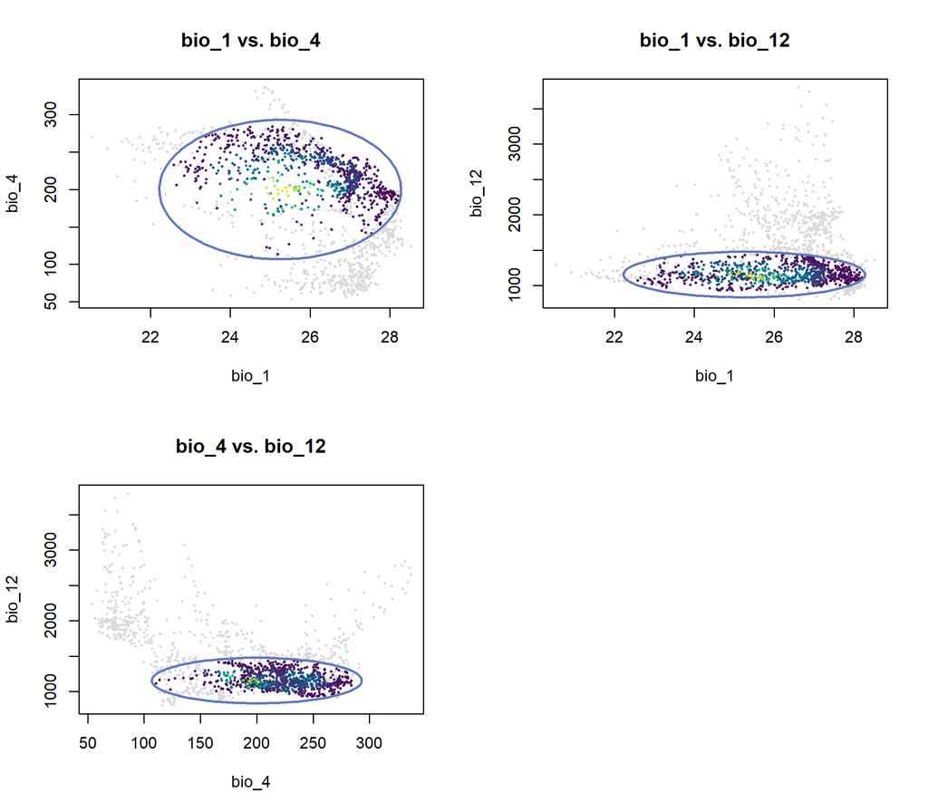

```r
# Score the background points, keeping the truncated suitability (0 = outside):
gen_bg <- predict(
  generalist,
  newdata               = back_data[, generalist$var_names],  # the niche's 3 variables
  include_suitability   = FALSE,
  include_mahalanobis   = FALSE,
  suitability_truncated = TRUE,
  verbose               = FALSE
)

# GENERALIST — every pairwise projection, coloured by suitability:
plot_ellipsoid_pairs(
  generalist,
  prediction = gen_bg,
  col_layer  = "suitability_trunc",   # colour the points by this column
  col_bg     = "#d9d9d9",             # grey = outside the niche
  col_ell    = "#5E78C4",             # ellipse boundary colour
  lwd = 2, pch = 16, cex_bg = 0.4
)
```

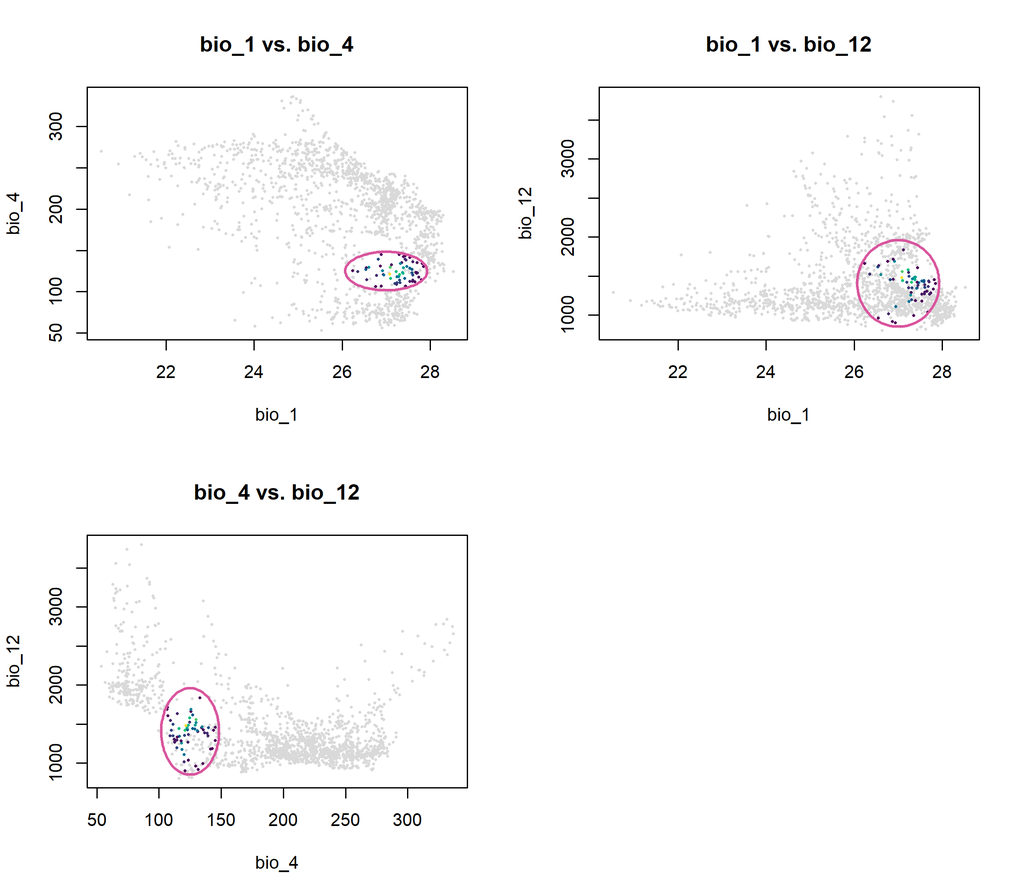

```r
# SPECIALIST — the same, for comparison:
spec_bg <- predict(
  specialist,
  newdata               = back_data[, specialist$var_names],
  include_suitability   = FALSE,
  include_mahalanobis   = FALSE,
  suitability_truncated = TRUE,
  verbose               = FALSE
)

plot_ellipsoid_pairs(
  specialist,
  prediction = spec_bg,
  col_layer  = "suitability_trunc",
  col_bg     = "#d9d9d9",
  col_ell    = "#D9559E",
  lwd = 2, pch = 16, cex_bg = 0.4
)
```

**What you should see.** Two multi-panel figures, one per niche. In every panel the **generalist**’s coloured (suitable) region fills a large part of the cloud, while the **specialist**’s coloured region is a small bright patch. Same landscape, different niche breadth — the punch line below.

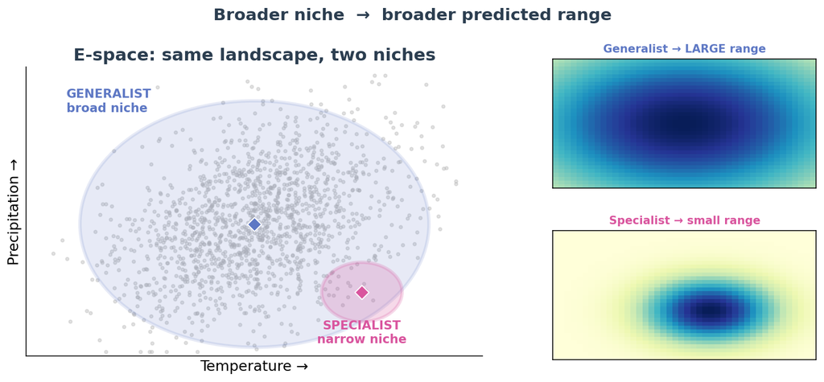